# Employee Attrition and Income Analysis

# Employee Attrition and Income Analysis

This project explores relationships between employee characteristics, attrition and monthly income using the IBM HR Analytics dataset.

## 1. Data Import and Inspection

Load the dataset and inspect its dimensions and structure.

```r
hrdata <- read.csv("HR-Employee-Attrition.csv")

dim(hrdata)
```

```
## [1] 1470   35
```

```r
head(hrdata)
```

```
##   Age Attrition    BusinessTravel DailyRate             Department
## 1  41       Yes     Travel_Rarely      1102                  Sales
## 2  49        No Travel_Frequently       279 Research & Development
## 3  37       Yes     Travel_Rarely      1373 Research & Development
## 4  33        No Travel_Frequently      1392 Research & Development
## 5  27        No     Travel_Rarely       591 Research & Development
## 6  32        No Travel_Frequently      1005 Research & Development
##   DistanceFromHome Education EducationField EmployeeCount EmployeeNumber
## 1                1         2  Life Sciences             1              1
## 2                8         1  Life Sciences             1              2
## 3                2         2          Other             1              4
## 4                3         4  Life Sciences             1              5
## 5                2         1        Medical             1              7
## 6                2         2  Life Sciences             1              8
##   EnvironmentSatisfaction Gender HourlyRate JobInvolvement JobLevel
```

[output cut: 41 more lines]

```r
str(hrdata)
```

```
## 'data.frame':    1470 obs. of  35 variables:
##  $ Age                     : int  41 49 37 33 27 32 59 30 38 36 ...
##  $ Attrition               : chr  "Yes" "No" "Yes" "No" ...
##  $ BusinessTravel          : chr  "Travel_Rarely" "Travel_Frequently" "Travel_Rarely" "Travel_Frequently" ...
##  $ DailyRate               : int  1102 279 1373 1392 591 1005 1324 1358 216 1299 ...
##  $ Department              : chr  "Sales" "Research & Development" "Research & Development" "Research & Development" ...
##  $ DistanceFromHome        : int  1 8 2 3 2 2 3 24 23 27 ...
##  $ Education               : int  2 1 2 4 1 2 3 1 3 3 ...
##  $ EducationField          : chr  "Life Sciences" "Life Sciences" "Other" "Life Sciences" ...
##  $ EmployeeCount           : int  1 1 1 1 1 1 1 1 1 1 ...
##  $ EmployeeNumber          : int  1 2 4 5 7 8 10 11 12 13 ...
##  $ EnvironmentSatisfaction : int  2 3 4 4 1 4 3 4 4 3 ...
##  $ Gender                  : chr  "Female" "Male" "Male" "Female" ...
##  $ HourlyRate              : int  94 61 92 56 40 79 81 67 44 94 ...
##  $ JobInvolvement          : int  3 2 2 3 3 3 4 3 2 3 ...
```

[output cut: 21 more lines]

## 2. Correlation Analysis

Examine relationships between selected numerical variables. Education is stored as an ordinal numerical code, so correlations involving this variable should be interpreted cautiously.

```r
# Create a list of numeric columns
num_cols <- c(
  "Age", "DailyRate", "DistanceFromHome",
  "Education", "HourlyRate", "MonthlyIncome",
  "MonthlyRate", "NumCompaniesWorked",
  "TotalWorkingYears", "TrainingTimesLastYear"
)

# Filter the data
hrdata_num <- hrdata[, num_cols]

# Calculate the correlation matrix
cor(hrdata_num)
```

```
##                               Age    DailyRate DistanceFromHome   Education
## Age                    1.00000000  0.010660943     -0.001686120  0.20803373
## DailyRate              0.01066094  1.000000000     -0.004985337 -0.01680643
## DistanceFromHome      -0.00168612 -0.004985337      1.000000000  0.02104183
## Education              0.20803373 -0.016806433      0.021041826  1.00000000
## HourlyRate             0.02428654  0.023381422      0.031130586  0.01677483
## MonthlyIncome          0.49785457  0.007707059     -0.017014445  0.09496068
## MonthlyRate            0.02805117 -0.032181602      0.027472864 -0.02608420
## NumCompaniesWorked     0.29963476  0.038153434     -0.029250804  0.12631656
## TotalWorkingYears      0.68038054  0.014514739      0.004628426  0.14827970
## TrainingTimesLastYear -0.01962082  0.002452543     -0.036942234 -0.02510024
##                         HourlyRate MonthlyIncome  MonthlyRate
## Age                    0.024286543   0.497854567  0.028051167
## DailyRate              0.023381422   0.007707059 -0.032181602
## DistanceFromHome       0.031130586  -0.017014445  0.027472864
## Education              0.016774829   0.094960677 -0.026084197
## HourlyRate             1.000000000  -0.015794304 -0.015296750
## MonthlyIncome         -0.015794304   1.000000000  0.034813626
## MonthlyRate           -0.015296750   0.034813626  1.000000000
## NumCompaniesWorked     0.022156883   0.149515216  0.017521353
## TotalWorkingYears     -0.002333682   0.772893246  0.026442471
## TrainingTimesLastYear -0.008547685  -0.021736277  0.001466881
##                       NumCompaniesWorked TotalWorkingYears
## Age                           0.29963476       0.680380536
## DailyRate                     0.03815343       0.014514739
## DistanceFromHome             -0.02925080       0.004628426
## Education                     0.12631656       0.148279697
## HourlyRate                    0.02215688      -0.002333682
## MonthlyIncome                 0.14951522       0.772893246
## MonthlyRate                   0.01752135       0.026442471
## NumCompaniesWorked            1.00000000       0.237638590
## TotalWorkingYears             0.23763859       1.000000000
## TrainingTimesLastYear        -0.06605407      -0.035661571
##                       TrainingTimesLastYear
## Age                            -0.019620819
## DailyRate                       0.002452543
## DistanceFromHome               -0.036942234
## Education                      -0.025100241
## HourlyRate                     -0.008547685
## MonthlyIncome                  -0.021736277
## MonthlyRate                     0.001466881
## NumCompaniesWorked             -0.066054072
## TotalWorkingYears              -0.035661571
## TrainingTimesLastYear           1.000000000
```

## 3. Scatterplot Analysis

First, examine monthly income, age and education. Education is an ordinal variable, so its values appear in discrete bands.

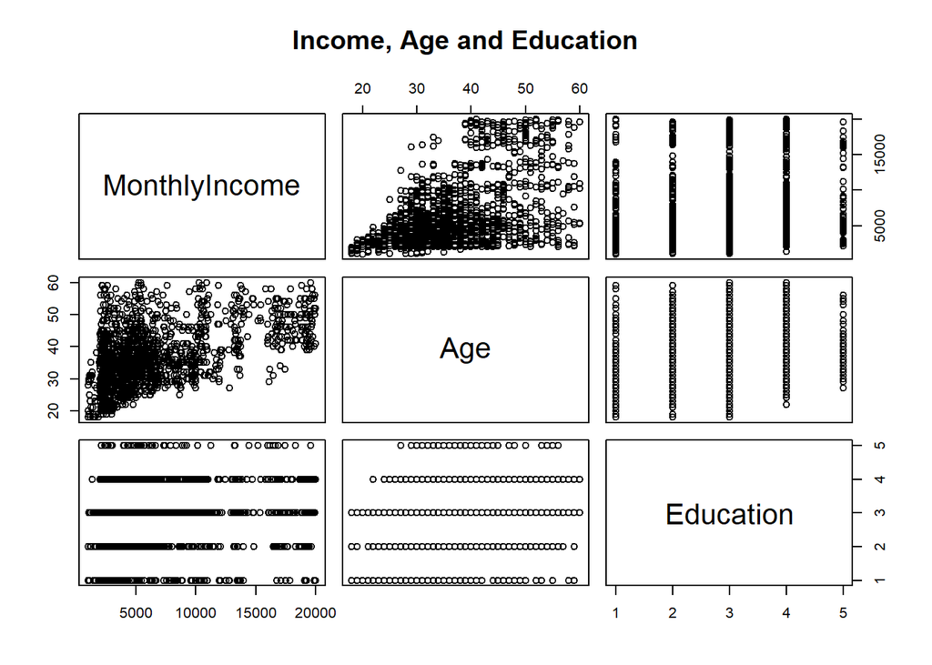

```r
pairs(
  ~ MonthlyIncome + Age + Education,
  data = hrdata,
  main = "Income, Age and Education"
)
```

Next, replace education with total working years to compare three numerical variables.

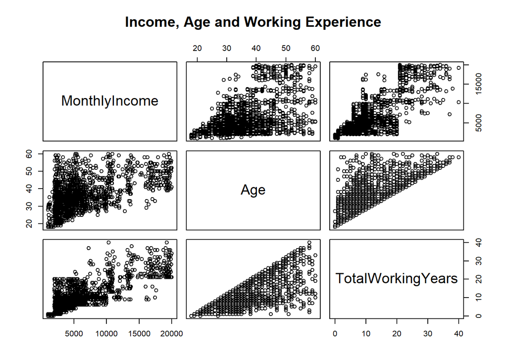

```r
pairs(
  ~ MonthlyIncome + Age + TotalWorkingYears,
  data = hrdata,
  main = "Income, Age and Working Experience"
)
```

## 4. Education-Level Analysis

Convert the education codes into labelled categories.

```r
hrdata$EducationLabel <- factor(
  hrdata$Education,
  levels = 1:5,
  labels = c(
    "Below College",
    "College",
    "Bachelor",
    "Master",
    "Doctor"
  ),
  ordered = TRUE
)

table(hrdata$EducationLabel, useNA = "ifany")
```

```
##
## Below College       College      Bachelor        Master        Doctor
##           170           282           572           398            48
```

### Age by Education Level

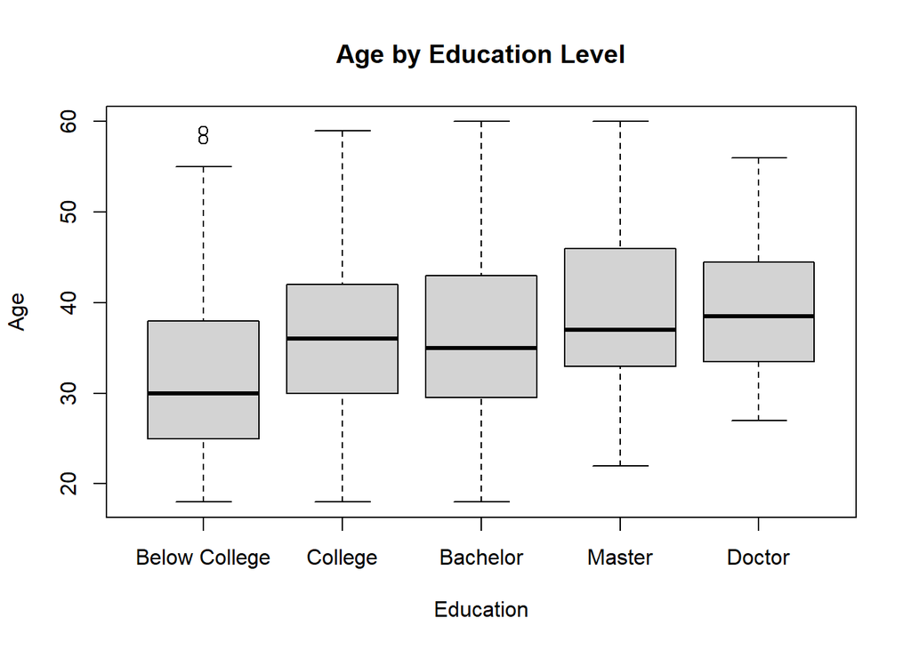

```r
boxplot(
  Age ~ EducationLabel,
  data = hrdata,
  main = "Age by Education Level",
  xlab = "Education",
  ylab = "Age",
  outline = TRUE,
  pch = 1
)
```

### Working Experience by Education Level

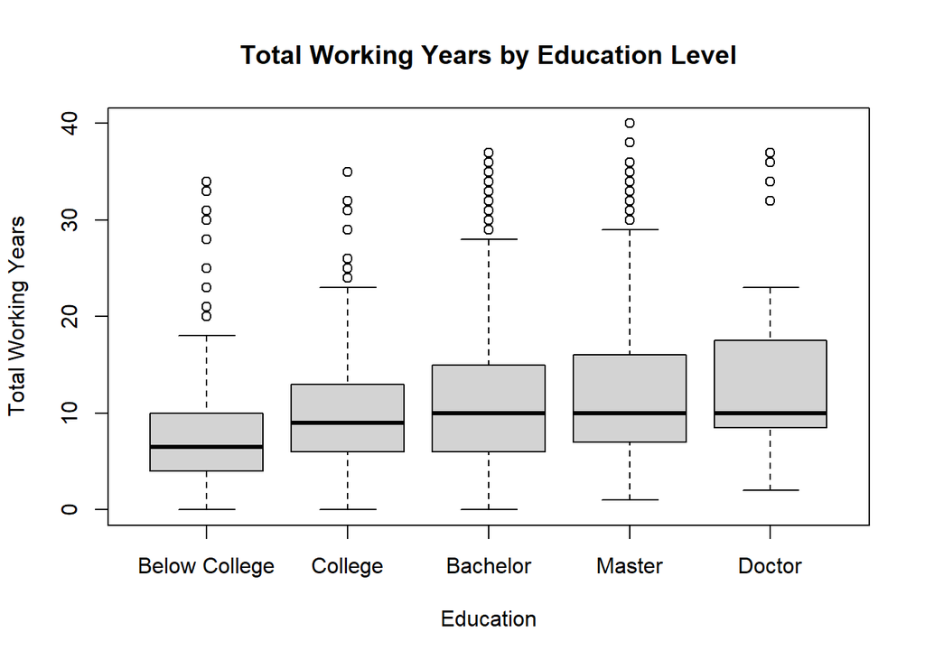

```r
boxplot(
  TotalWorkingYears ~ EducationLabel,
  data = hrdata,
  main = "Total Working Years by Education Level",
  xlab = "Education",
  ylab = "Total Working Years",
  outline = TRUE,
  pch = 1
)
```

### Monthly Income by Education Level

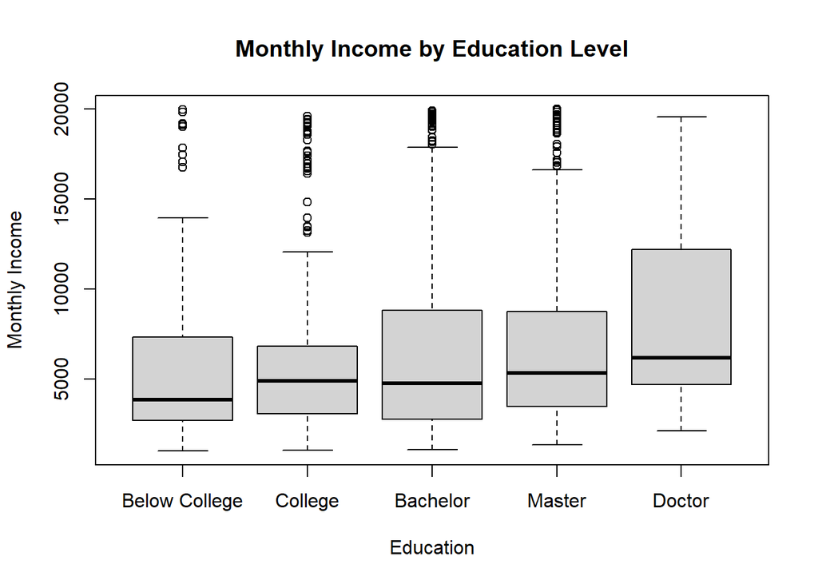

```r
boxplot(
  MonthlyIncome ~ EducationLabel,
  data = hrdata,
  main = "Monthly Income by Education Level",
  xlab = "Education",
  ylab = "Monthly Income",
  outline = TRUE,
  pch = 1
)
```

## 5. Employee Attrition and Age

Investigate whether employees who left the organisation differ in age from those who remained.

### Age Distribution by Attrition

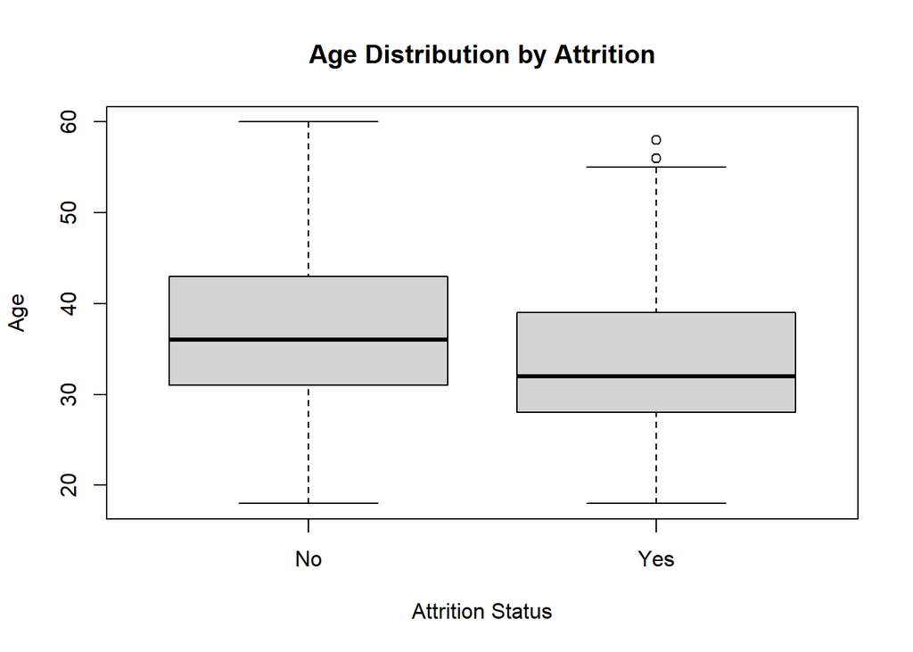

```r
boxplot(
  Age ~ Attrition,
  data = hrdata,
  main = "Age Distribution by Attrition",
  xlab = "Attrition Status",
  ylab = "Age"
)
```

### Independent-Samples t-Test

Test whether the mean age differs between employees with and without attrition.

```r
yes_age <- hrdata[
  hrdata$Attrition == "Yes", "Age"
]

no_age <- hrdata[
  hrdata$Attrition == "No", "Age"
]

t.test(yes_age, no_age)
```

```
##
##  Welch Two Sample t-test
##
## data:  yes_age and no_age
## t = -5.828, df = 316.93, p-value = 1.38e-08
## alternative hypothesis: true difference in means is not equal to 0
## 95 percent confidence interval:
##  -5.288346 -2.618930
## sample estimates:
## mean of x mean of y
##  33.60759  37.56123
```

The default Welch two-sample t-test evaluates whether the group means differ while allowing for unequal variances.

## 6. Simple Linear Regression

Examine the relationship between employee age and monthly income.

```r
model1 <- lm(
  MonthlyIncome ~ Age,
  data = hrdata
)

summary(model1)
```

```
##
## Call:
## lm(formula = MonthlyIncome ~ Age, data = hrdata)
##
## Residuals:
##     Min      1Q  Median      3Q     Max
## -9990.1 -2592.7  -677.9  1810.5 12540.8
##
## Coefficients:
##             Estimate Std. Error t value Pr(>|t|)
## (Intercept) -2970.67     443.70  -6.695 3.06e-11 ***
## Age           256.57      11.67  21.995  < 2e-16 ***
## ---
## Signif. codes:  0 '***' 0.001 '**' 0.01 '*' 0.05 '.' 0.1 ' ' 1
##
## Residual standard error: 4084 on 1468 degrees of freedom
## Multiple R-squared:  0.2479, Adjusted R-squared:  0.2473
## F-statistic: 483.8 on 1 and 1468 DF,  p-value: < 2.2e-16
```

## 7. Multiple Linear Regression

Extend the model by including total working years alongside age.

This allows us to examine the association between age and monthly income while accounting for employees’ accumulated working experience, and vice versa.

```r
model2 <- lm(
  MonthlyIncome ~ Age + TotalWorkingYears,
  data = hrdata
)

summary(model2)
```

```
##
## Call:
## lm(formula = MonthlyIncome ~ Age + TotalWorkingYears, data = hrdata)
##
## Residuals:
##      Min       1Q   Median       3Q      Max
## -11310.8  -1690.8    -91.4   1428.3  11461.5
##
## Coefficients:
##                   Estimate Std. Error t value Pr(>|t|)
## (Intercept)        1978.08     352.36   5.614 2.36e-08 ***
## Age                 -26.87      11.63  -2.311    0.021 *
## TotalWorkingYears   489.13      13.65  35.824  < 2e-16 ***
## ---
## Signif. codes:  0 '***' 0.001 '**' 0.01 '*' 0.05 '.' 0.1 ' ' 1
##
## Residual standard error: 2984 on 1467 degrees of freedom
## Multiple R-squared:  0.5988, Adjusted R-squared:  0.5983
## F-statistic:  1095 on 2 and 1467 DF,  p-value: < 2.2e-16
```

## 8. Interpretation and Limitations

The statistical results above should be interpreted by examining group means, effect sizes, p-values, confidence intervals and regression coefficients.

The analysis is observational. Associations do not establish causality, and omitted variables may influence the observed relationships.